# With PyTorch

- Define by Run의 장점  
  즉시 확인 가능 -> pythonic code
- GPU support, Good API and community
- 사용하기 편함
- TF는 production과 scalability의 장점

# PyTorch = Numpy + AutoGrad + Function

- numpy 구조를 가지는 Tensor객체로 array 표현
- 자동미분을 지원하여 DL연산을 지원
- 다양한 형태의 DL을 지원하는 함수와 모델을 지원함

## Tensor

- 다차원 Arrays를 표현하는 PyTorch 클래스
- 사실상 numpy의 ndarray와 동일  
  (Tensorflow의 Tensor와도 동일)
- Tensor를 생성하는 함수도 거의 동일

```python
#numpy - ndarray
import numpy as np
n_array = np.arange(10).reshape(2,5)
print(n_array)
print(f'ndim : {n_array.ndim}, shape : {n_array.shape}')
print()

#pytorch = tensor
import torch
t_array = torch.FloatTensor(n_array)
print(t_array)
print(f'ndim : {t_array.ndim}, shape : {t_array.shape}')
```

```
[[0 1 2 3 4]
 [5 6 7 8 9]]
ndim : 2, shape : (2, 5)

tensor([[0., 1., 2., 3., 4.],
        [5., 6., 7., 8., 9.]])
ndim : 2, shape : torch.Size([2, 5])
```

## Array to Tensor

Tensor 생성은 list나 ndarray 사용 가능

```python
# data to tensor
data = [[3,5], [10,5]]
x_data = torch.tensor(data)
x_data
```

```
tensor([[ 3,  5],
        [10,  5]])
```

```python
# ndarray to tensor
nd_array_ex = np.array(data)
tensor_array = torch.from_numpy(nd_array_ex)
tensor_array
```

```
tensor([[ 3,  5],
        [10,  5]], dtype=torch.int32)
```

기본적으로 tensor가 가질수 있는 데이터타입은 numpy와 동일하다. 또한 numpy의 사용법이 tensor에 대부분 그대로 적용된다.

```python
data = [[3,5,20],[10,5,50],[1,5,10]]
x_data = torch.tensor(data)
x_data
```

```
tensor([[ 3,  5, 20],
        [10,  5, 50],
        [ 1,  5, 10]])
```

```python
#슬라이싱
print(x_data[1:])
print(x_data[:2,1:])
print()

#flatten()
print(x_data.flatten())
print()

#ones_like()
print(torch.ones_like(x_data))
print()

#numpy()
print(x_data.numpy())
print()

#shape
print(x_data.shape)
print()

#dtype
print(x_data.dtype)
```

```
tensor([[10,  5, 50],
        [ 1,  5, 10]])
tensor([[ 5, 20],
        [ 5, 50]])

tensor([ 3,  5, 20, 10,  5, 50,  1,  5, 10])

tensor([[1, 1, 1],
        [1, 1, 1],
        [1, 1, 1]])

[[ 3  5 20]
 [10  5 50]
 [ 1  5 10]]

torch.Size([3, 3])

torch.int64
```

**pytorch의 tensor는 GPU에 올려서 사용이 가능하다.**

```python
x_data.device  #device(type='cpu')

if torch.cuda.is_available():
    x_data_cuda = x_data.to('cuda') # GPU 사용할때는 cuda로 나옴
x_data_cuda.device
```

[output not shown]

## Tensor handling

view, squeeze, unsqueeze 등으로 tensor조정가능

- view : reshpae과 동일하게 tensor의 shape을 변환
- squeeze : 차원의 개수가 1인 차원을 삭제(압축)
- unsqueeze : 차원의 개수가 1인 차원을 추가

```python
tensor_ex = torch.rand(size = (2,3,2))
print(tensor_ex)

print(tensor_ex.view([-1,6]))
print(tensor_ex.reshape([-1,6]))
```

```
tensor([[[0.9317, 0.9572],
         [0.4106, 0.2303],
         [0.2835, 0.1358]],

        [[0.5032, 0.8471],
         [0.1256, 0.9591],
         [0.7993, 0.6677]]])
tensor([[0.9317, 0.9572, 0.4106, 0.2303, 0.2835, 0.1358],
        [0.5032, 0.8471, 0.1256, 0.9591, 0.7993, 0.6677]])
tensor([[0.9317, 0.9572, 0.4106, 0.2303, 0.2835, 0.1358],
        [0.5032, 0.8471, 0.1256, 0.9591, 0.7993, 0.6677]])
```

**reshape과 view의 차이**

view는 기존 메모리 값을 그대로 받아오고 reshape은 copy해서 받아오기 때문에 기존 값이 변경된다고 해서 copy한 값이 바뀌지는 않는다.

```python
a = torch.zeros(3,2)
b = a.view(2,3)
print(a.fill_(1))
print(b)
```

```
tensor([[1., 1.],
        [1., 1.],
        [1., 1.]])
tensor([[1., 1., 1.],
        [1., 1., 1.]])
```

```python
a = torch.zeros(3,2)
b = a.t().reshape(6)
print(a.fill_(1))
print(b)
```

```
tensor([[1., 1.],
        [1., 1.],
        [1., 1.]])
tensor([0., 0., 0., 0., 0., 0.])
```

**squeeze, unsqueeze**

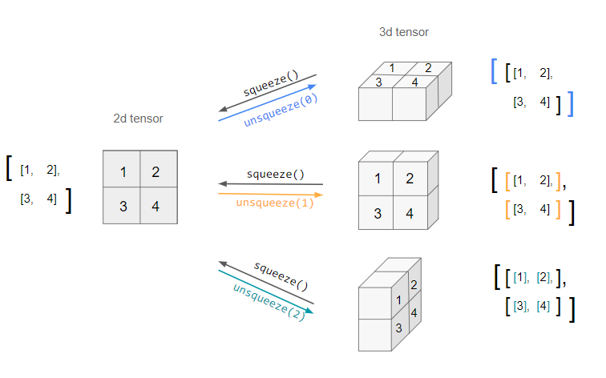

```python
tensor_ex = torch.rand(size = (2,1,2))
print(tensor_ex.squeeze())
print()

tensor_ex = torch.rand(size = (2,2))
print(tensor_ex.unsqueeze(0).shape)
print(tensor_ex.unsqueeze(1).shape)
print(tensor_ex.unsqueeze(2).shape)
```

```
tensor([[0.0361, 0.7890],
        [0.7984, 0.2194]])

torch.Size([1, 2, 2])
torch.Size([2, 1, 2])
torch.Size([2, 2, 1])
```

## Tensor operations

기본적인 tensor의 operations는 numpy와 동일

```python
n1 = np.arange(10).reshape(2,5)
t1 = torch.FloatTensor(n1)

print(t1+t1)
print(t1-t1)
print(t1+10)
```

```
tensor([[ 0.,  2.,  4.,  6.,  8.],
        [10., 12., 14., 16., 18.]])
tensor([[0., 0., 0., 0., 0.],
        [0., 0., 0., 0., 0.]])
tensor([[10., 11., 12., 13., 14.],
        [15., 16., 17., 18., 19.]])
```

**단, 행렬곱셈 연산은 함수 `dot()`이 아닌 `mm()`을 사용**

```python
n2 = np.arange(10).reshape(5,2)
t2 = torch.FloatTensor(n2)

print(t1.mm(t2))
# print(t1.dot(t2))  # RuntimeError
print(t1.matmul(t2))
```

```
tensor([[ 60.,  70.],
        [160., 195.]])
tensor([[ 60.,  70.],
        [160., 195.]])
```

```python
a = torch.rand(10)
b = torch.rand(10)
print(a.dot(b))
print(a.mm(b))  #RuntimeError :  mm은 스칼라 연산 지원하지 않음
```

```
tensor(2.3907)
```

```
---------------------------------------------------------------------------
RuntimeError                              Traceback (most recent call last)
Input In [37], in <cell line: 4>()
      2 b = torch.rand(10)
      3 print(a.dot(b))
----> 4 print(a.mm(b))

RuntimeError: self must be a matrix
```

**mm과 matmul은 broadcasting 지원 차이**  
mm은 broadcasting 지원을 하지 않는다.  
matmul에서 보통 0번째 인덱스는 batch를 나타낸다. 따라서 torch.rand(5,2,3)은 2x3 행렬을 5번 연산하는 것과 같다.

```python
# 연산 불가
a = torch.rand(5,2,3)
b = torch.rand(5)
a.mm(b)
```

```
---------------------------------------------------------------------------
RuntimeError                              Traceback (most recent call last)
Input In [38], in <cell line: 3>()
      1 a = torch.rand(5,2,3)
      2 b = torch.rand(5)
----> 3 a.mm(b)

RuntimeError: self must be a matrix
```

```python
 # 연산 가능
a = torch.rand(5,2,3)
b = torch.rand(3)
a.matmul(b)
```

```
tensor([[0.3145, 0.6112],
        [0.9938, 0.4425],
        [0.5239, 1.0226],
        [0.8727, 0.9882],
        [0.6309, 0.6055]])
```

```python
# matmul과 결과가 같음
print(a[0].mm(torch.unsqueeze(b,1)).squeeze())
print(a[1].mm(torch.unsqueeze(b,1)).squeeze())
print(a[2].mm(torch.unsqueeze(b,1)).squeeze())
print(a[3].mm(torch.unsqueeze(b,1)).squeeze())
print(a[4].mm(torch.unsqueeze(b,1)).squeeze())
```

```
tensor([0.3145, 0.6112])
tensor([0.9938, 0.4425])
tensor([0.5239, 1.0226])
tensor([0.8727, 0.9882])
tensor([0.6309, 0.6055])
```

## Tensor operations for ML/DL formula

nn.functional 모듈을 통해 다양항 수식 변환을 지원함

```python
import torch
import torch.nn.functional as F

tensor = torch.FloatTensor([0.5, 0.7, 0.1])
h_tensor = F.softmax(tensor, dim = 0)
print(h_tensor)

y = torch.randint(5, (10,5))
y_label = y.argmax(dim=1)
print(y_label)
torch.nn.functional.one_hot(y_label)
```

```
tensor([0.3458, 0.4224, 0.2318])
tensor([2, 4, 2, 2, 1, 3, 0, 3, 2, 3])
```

```
tensor([[0, 0, 1, 0, 0],
        [0, 0, 0, 0, 1],
        [0, 0, 1, 0, 0],
        [0, 0, 1, 0, 0],
        [0, 1, 0, 0, 0],
        [0, 0, 0, 1, 0],
        [1, 0, 0, 0, 0],
        [0, 0, 0, 1, 0],
        [0, 0, 1, 0, 0],
        [0, 0, 0, 1, 0]])
```

```python
import itertools
a = [1,2,3]
b = [4,5]
print(list(itertools.product(a,b)))

tensor_a = torch.tensor(a)
tensor_b = torch.tensor(b)
torch.cartesian_prod(tensor_a, tensor_b)
```

```
[(1, 4), (1, 5), (2, 4), (2, 5), (3, 4), (3, 5)]
```

```
tensor([[1, 4],
        [1, 5],
        [2, 4],
        [2, 5],
        [3, 4],
        [3, 5]])
```

## Autograd

PyTorch의 핵심은 자동 미분의 지원 -> backward 함수 사용

```python
w = torch.tensor(2.0, requires_grad = True)
y = w**2
z = 10*y+25

z.backward() #미분
w.grad
```

```
tensor(40.)
```

```python
#편미분
a = torch.tensor([2.,3.], requires_grad = True)
b = torch.tensor([6., 4.], requires_grad = True)
Q = 3*a**3 - b**2
external_grad = torch.tensor([1.,1.])
Q.backward(gradient = external_grad)

print(a.grad)
print(b.grad)
```

```
tensor([36., 81.])
tensor([-12.,  -8.])
```